# Fitting disease models to data

## Exercise 2: Compare the SIBR model to data

> Play around with different values of $\beta$, $\gamma$, and $\delta$ in the SIBR model to see if you can make an epidemic curve that looks something like the plot above. Try starting with $\beta = 2$, $\gamma = 1/3$ and $\delta = 1 / 3$. Start with the initial conditions as $S_0 = 762$, $I_0=1$, $B_0 = 0$, $R_0 = 0$. Remember that the observed data is describing $B$, the number of boys in bed, so you will want to compare the $B$ trajectory from the model to the observed data.

```r
# HIDE ME IF YOU DON'T WANT TO SEE THE ANSWER
# library(deSolve)
# Set parameters and initial conditions
params = c(beta=2.3, gamma=0.8, delta=0.4)
xinit = c(S=762, I=1, B=0, R=0)
# Set times at which we want to solve ODE
times = seq(0, 15, by=1/4)
# Run ODE model. Note that `ode` is generic wrapper for `lsoda` with the same parameters. By default `ode`
# uses the `lsoda` solver, but you can specify other solvers using the `method` argument.
ode_res = as.data.frame(ode(xinit, times, sibr_model, params))
```

Plot the trajectories for I and B

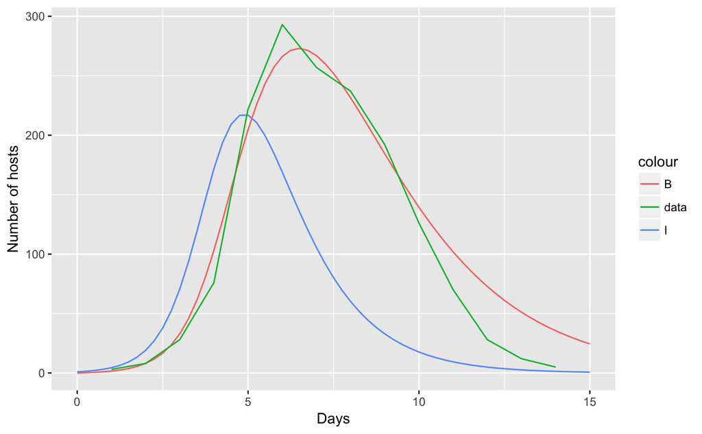

```r
# HIDE ME IF YOU DON'T WANT TO SEE THE ANSWER
# ggplot
ggplot(ode_res, aes(x=time, y=I, color="I")) +
    geom_line() + geom_line(aes(x=time, y=B, color="B")) +
    geom_line(data=flu, aes(x=day, y=flu, color="data")) +
    xlab("Days") + ylab("Number of hosts")
```

```r
# Or base plot
plot(ode_res$time, ode_res$I, col="blue", type="l", ylab="Number of hosts", xlab="Days", ylim=c(0, 500))
lines(ode_res$time, ode_res$B, col="red")
```

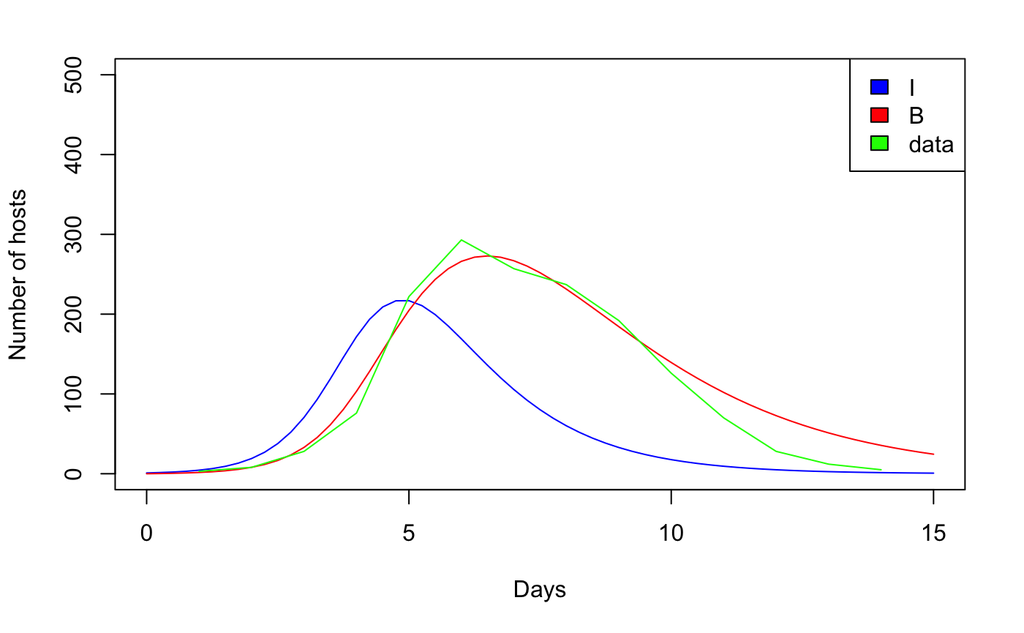

```r
lines(flu$day, flu$flu, col="green")
legend("topright", legend=c("I", "B", "data"), fill=c("blue", "red", "green"))
```

## Fitting the SIBR model to data with trajectory matching

You just tried a bunch of different parameter combinations and examined whether or not they produced a good fit to the observed flu data. Perhaps you found a combination of parameters that looked “pretty good”, but didn’t fit the data exactly. You might have even asked yourself *How do I know that this parameter set produces a “better” fit than another parameter set?*

This is an incredibly important question and one we will discuss in the following sections. But first let’s consider two types of error that can influence our observations: **process error** and **measurement error**.

### Process error vs. measurement error

Following Bolker (2008, Chapter 11 in [Ecological Models and Data in R](https://ms.mcmaster.ca/~bolker/emdbook/chap11A.pdf)), let’s consider a simple discrete time model given by

$$X_t = a + b X_{t - 1}$$

if $|b| < 1$ this model has an equilibrium value of $\frac{a}{1 - b}$. To get a sense of the deterministic model let’s simulate it.

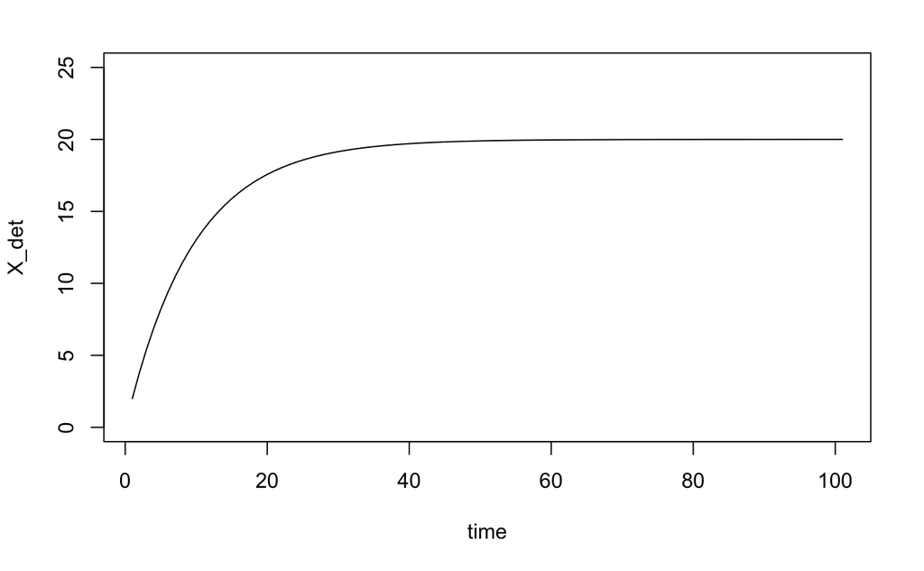

```r
# Initial set up
time_steps = 100
a = 2 # p
b = 0.9
X_init = 2
# Array to hold results
X_det = array(NA, dim=time_steps + 1)
X_det[1] = X_init
# For loop to step through the model
for(t in 2:(time_steps + 1)){
  X_det[t] = a + b * X_det[t - 1]
}
# Plot the simulation
time = 1:(time_steps + 1)
plot(time, X_det, type="l", ylim=c(0, 25))
```

Pure **measurement error** assumes that there is an underlying deterministic model, but each observation is observed with some error. Assuming normally distributed measurement error, this corresponds to

$$\begin{align}
X_t &= a + b X_{t - 1} \\
X_{t, obs} &= X_t + Z_t \\
Z_t &\sim N(0, \sigma_{obs})
\end{align}$$

Where $X_{t, obs}$ is the value we actually observed at time $t$ and $X_t$ is the true value. Notice that the error $Z_t$ does not affect $X_{t + 1}$, just how we observe the true $X_t$. In other words, $Z_t$ is independent of the errors $Z_{t + h}$ for $h \neq 0$ and independent of $X_{t}$. In R, measurement error can be incorporated through the following simulation

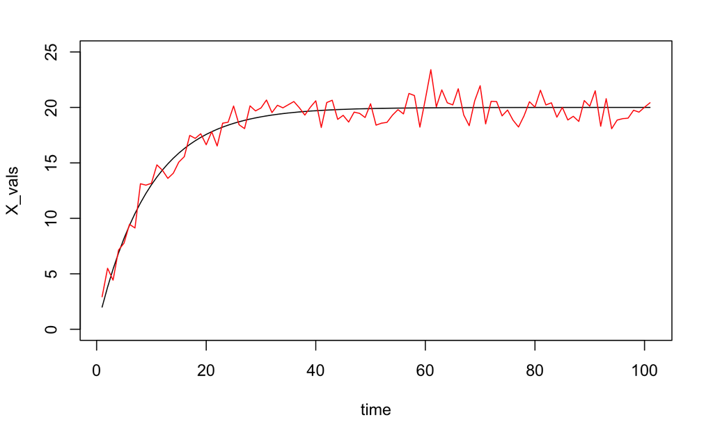

```r
# Initial set up
time_steps = 100
a = 2 # Intercept
b = 0.9 # Slope
sigma_obs = 1 # Measurement error standard deviation
X_init = 2 # Initial X value
# Starting arrays
X_vals = array(NA, dim=time_steps + 1)
X_obs = array(NA, dim=time_steps + 1)
X_vals[1] = X_init
X_obs[1] = X_init + rnorm(1, mean=0, sd=sigma_obs)
# For loop step through the model
for(t in 2:(time_steps + 1)){

  # These are the equations defined above
  X_vals[t] = a + b * X_vals[t - 1]
  X_obs[t] = X_vals[t] + rnorm(1, mean=0, sd=sigma_obs) # add measurement error

}
# Plot the simulation
time = 1:(time_steps + 1)
plot(time, X_vals, type="l", ylim=c(0, 25))
lines(time, X_obs, col="red")
```

In contrast, pure **process error** assumes that the stochasticity (i.e. randomness of some type) is part of the process and observations are made without error. Assuming normally distributed, white noise process error this would look like

$$\begin{align}
X_t &= a + b X_{t - 1} + Z_t \\
X_{t, obs} &= X_t \\
Z_t &\sim N(0, \sigma_{proc})
\end{align}$$

Notice that now the error $Z_t$ is influencing the true value $X_t$, but there is no error when we measure $X_t$ (i.e. $X_{t, obs} = X_t$). This means that while the error $Z_t$ is still independent of $Z_{t + h}$ for $h \neq 0$ (same as with measurement error), $Z_t$ is now correlated with $X_t$ for $t \geq 0$ (this is not the case for measurement error).

Let’s get a sense of how this pure **process error** looks compared to pure **measurement error** via a simulation.

```r
# Initial set up
time_steps = 100
a = 2 # Intercept
b = 0.9 # Slope
sigma_proc = 1 # Measurement error
X_init = 2 # Initial X value
# Starting arrays
X_vals = array(NA, dim=time_steps + 1)
X_vals[1] = X_init
# For loop to step through the model
for(t in 2:(time_steps + 1)){

  # Add process error
  X_vals[t] = a + b * X_vals[t - 1] +  + rnorm(1, mean=0, sd=sigma_proc)
}
# Plot the simulation
time = 1:(time_steps + 1)
plot(time, X_vals, type="l", ylim=c(0, 25), col="blue")
lines(time, X_det, col="black")
```

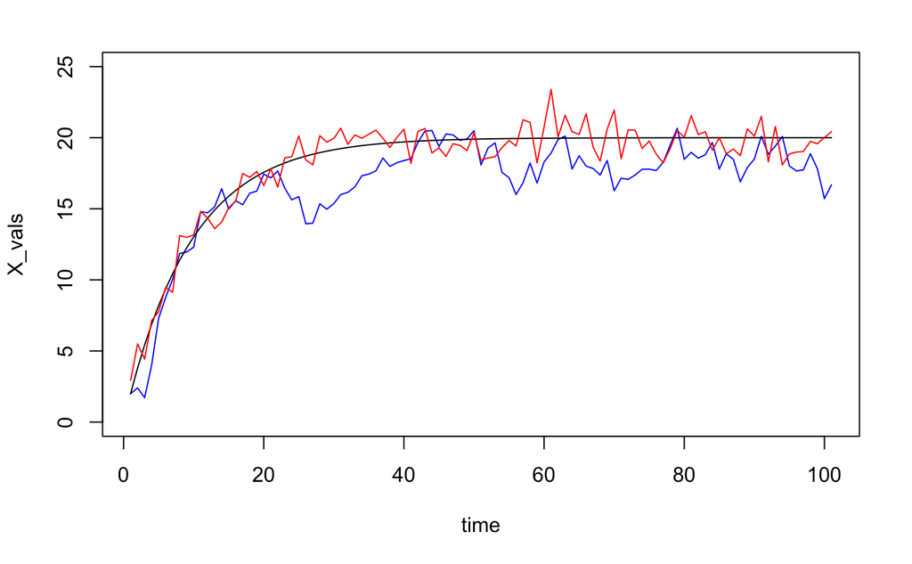

```r
lines(time, X_obs, col="red")
```

Notice that the model with process error looks qualitatively very different than the model with measurement error. This is because now there is auto-correlation between the process error at time $t$ and the model output at time $t + h$ (for $h \geq 0$).

Depending on the type of error, we will need different methods for fitting the model. And if there are both types of error, which happens quite frequently, things get even more complicated (for example, [here are some cutting-edge tools](http://kingaa.github.io/pomp/docs.html) for this situation)! Today we will just consider fitting models with *measurement error*.

### Trajectory matching and least squares

Assuming that we just have measurement error, let’s return to our question

*How do I know that this parameter set produces a “better” fit than another parameter set?*

One simple way to identify a “best” parameter set is to find the one that minimizes the criteria known as “sum of squared errors” (SSE). This is just like you learned in linear regression where the residual (i.e. error) is defined as “observed data point - data point predicted by the model”. Sum of squared errors is the sum of squared residuals (errors) for all data points in the data set. Mathematically, this is defined as

$$SSE = \sum_{t=1}^{n} (Y_{t, \text{obs}} - Y_{t, \text{pred}})^2$$
where $n$ is the number of data points, $Y_{t, \text{obs}}$ is the observed point at time $t$, and $Y_{t, \text{pred}}$ is the prediction of the model at time $t$. Note that while there are good, theoretical reasons to minimize the SSE to identify the “best” parameters, there are other criteria that you could use as well (e.g. sum of absolute errors).

To find the parameter set that minimizes the SSE we first need to be able to calculate the SSE for a single parameter set. Let’s use our flu data and SIBR model to do this in the following steps.

1. First, let’s define the parameter set $\beta = 2$, $\gamma = 1/3$ and $\delta = 1 / 3$.

```r
# Parameters we are using to simulate model
params = c(beta=2, gamma=1/3, delta=1/3)
```

2. Second, let’s use this parameter set to simulate the SIBR model and extract the model-predicted number of boys confined to bed ($B$ in the model) *for the same time points at which we have observed data*. This gives us the **predicted** data given our model.

```r
# Time points observed in the data are given by flu$day and 0 is the time at the initial condition
times = c(0, flu$day)
# Initial conditions
init_vals = c(S=762, I=1, B=0, R=0)
# Simulate the model
pred = as.data.frame(ode(y=init_vals, func=sibr_model, parms = params, times = times))
# Extract B from the model. Don't include the initial value because that is not in the data.
predB = pred$B[2:15]
```

3. Compute the residuals/errors for the observed data and the predicted data

```r
# Extract observed data
obsB = flu$flu
# Compute residuals
errors = obsB - predB
errors
```

```
 [1]    2.23997260    3.53211289    6.46329301   -0.00480409   60.88462249   66.59251622    3.58028360  -13.79371818  -38.77923980  -76.62657238 -102.23036488 -114.97521058 -104.58062532
[14]  -88.73353857
```

4. Compute the sum of squared residuals

```r
# Compute the sum of squared error between observed and predicted
sse = sum(errors^2)
print(sse)
```

```
[1] 58260.41
```

### Exercise 3: Write a function to compute SSE for the SIBR model

> Turn what we just did into a function called `sse_sibr` that takes two arguments: a vector of parameters and a data.frame with columns `day` and `flu`. Have the function returns the SSE from for the given parameter set and the data. Test that it gives the same answer as the code above.

```r
# HIDE ME IF YOU DON'T WANT TO SEE THE ANSWER
sse_sibr = function(params, data){
  # Calculates SSE given flu data and SIBR model
  #
  # params : initial vector of parameters
  # data : flu data
  #
  # returns sum of squared errors

  times = c(0, data$day)
  init_vals = c(S=762, I=1, B=0, R=0)
  pred = as.data.frame(ode(y=init_vals, func=sibr_model, parms = params, times = times))

  predB = pred$B[2:length(times)] # don't include the intial value
  obsB = data$flu

  # Compute the sum of squared error between observed and predictsion
  sse = sum((obsB - predB)^2)
  return(sse)
}
sse_sibr(params, flu)
```

```
[1] 58260.41
```

### Minimizing SSE to find the best fit parameters

Now we want to find a combination of $\beta$, $\gamma$, and $\delta$ that minimizes the SSE as these, based on our definition, will be the “best” parameters given our model and data. `R` makes this really easy to do with the function `optim`. `optim` is a powerful function that implements many different efficient minimization routines. You can read more about it by typing `?optim`.

In our context, we can use it as follows

```r
# Find the parameter vector that minimzes the SSE
fit0 = optim(params, sse_sibr, data=flu)
```

The `optim` function requires three arguments

1. `params`: an initial set of parameters to optimize over
2. `sse_sibr`: a function to be minimized
3. `data=flu`: Any additional arguments to the function that is being minimized (in our case the dataset).

We save the results of `optim` to `fit0` which has the following attributes

1. `fit0$par` gives the set of parameters that minimized the SSE

```r
fit0$par
```

```
     beta     gamma     delta
2.4027467 0.9090060 0.4123379
```

2. `fit0$value` gives the value of the function (in this case the sum of squared errors) corresponding to the estimated parameters.

```r
fit0$value
```

```
[1] 6063.937
```

This is much better/smaller than our starting parameter value of 58260.41.

3. `fit0$convergence` tells whether the routine converged (i.e. successfully found a minimum). A value of 0 for this means that it worked.

```r
fit0$convergence
```

```
[1] 0
```

The first set of parameters isn’t always the best. You can re-run the optimization procedure, starting at your previous best fit:

```r
fit1 <- optim(fit0$par, sse_sibr, data=flu)
fit1$par
```

```
     beta     gamma     delta
2.4029047 0.9092372 0.4123194
```

Finally, we can plot the resulting dynamics from the parameters that minimize the sum of squared errors to see if the results actually make any sense.

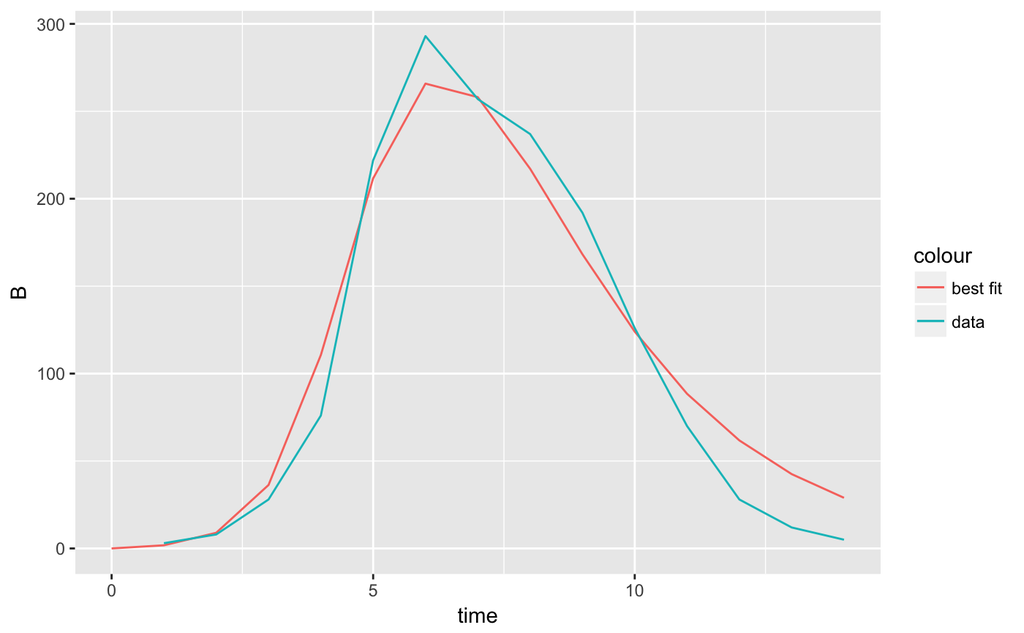

```r
# Run the model with the best parameters
best_params_lsq = fit1$par
best_mod_lsq = as.data.frame(ode(times=times, y=init_vals, parms=best_params_lsq, func=sibr_model))
# Plot the results
ggplot(best_mod_lsq, aes(x=time, y=B, color="best fit")) + geom_line() +
    geom_line(data=flu, aes(x=day, y=flu, color="data"))
```

```r
# or in base plot
plot(best_mod_lsq$time, best_mod_lsq$B, col="red", type="l", ylab="B", xlab="Days", ylim=c(0, 350))
lines(flu$day, flu$flu, col="blue")
```

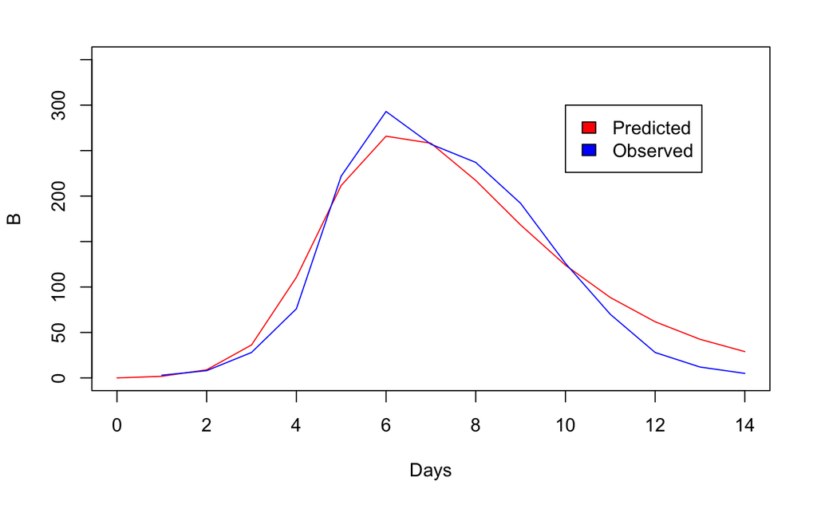

```r
legend(10, 300, legend=c("Predicted", "Observed"), fill=c("red","blue"))
```

As we’d expect given measurement error, the fit is not perfect, but minimizing SSE allows us to capture the the major features of the influenza outbreak.

## Trajectory matching with maximum likelihood

One of the multiple reasons that SSE is often used to estimate parameters is because it provides equivalent parameter estimates as assuming that our measurement error is normally (Gaussian) distributed. However, sum of squared errors estimation in and of itself does not provide us with a way to get confidence intervals around our predictions. Confidence intervals are useful if we wanted to, say, calculate the uncertainty around the predicted $R_0$ in our model. To do this, we need to allow the measurement error to follow some distribution (e.g. Normal, Poisson, Binomial, etc.).

Specifying a distribution for our measurement error allows us to use **maximum likelihood** to fit the model. Likelihood is defined as the *the likelihood of a set of parameters given the data*. Similar to using SSE, we can say that a parameter set is “better” if it has a higher likelihood than another parameter set, given the data. We can find the the “best” parameter set for our data by finding the parameter set that **maximizes the likelihood given the data**.

Ok, but how do we use likelihood? A couple of definitions are helpful.

Given a parameter vector $\Theta$ (think, for example, $\Theta = [\beta, \gamma, \delta]$) and some data vector $Y = y_1, y_2, \dots, y_t$ the likelihood ($L$) is defined as

$$L(\Theta | Y) = p(Y | \Theta)$$

where $p(Y | \Theta)$ is (roughly) the probability of the data ($Y$) given the parameters ($\Theta$). In many cases, we assume that the our data points are independent. (Note that this is not always reasonable, particularly when considering process error. In this case, we often need to use rules of conditional and marginal probability to re-write our likelihood. This is beyond the scope of what we are doing today.)

Given the assumption of independence, we can write

$$L(\Theta | Y) = \prod_{t=1}^n p(y_t | \Theta)$$

As a quick example, assume that we have a very simple model

$$\begin{align}
Y_t &= \mu + Z_t \\
Z_t &\sim \text{Normal}(0, \sigma)
\end{align}$$

The model is just the value $\mu$ through time with some Normal error around it. We can simulate 100 data points from this simple model letting $\mu = 5$ and $\sigma = 2$.

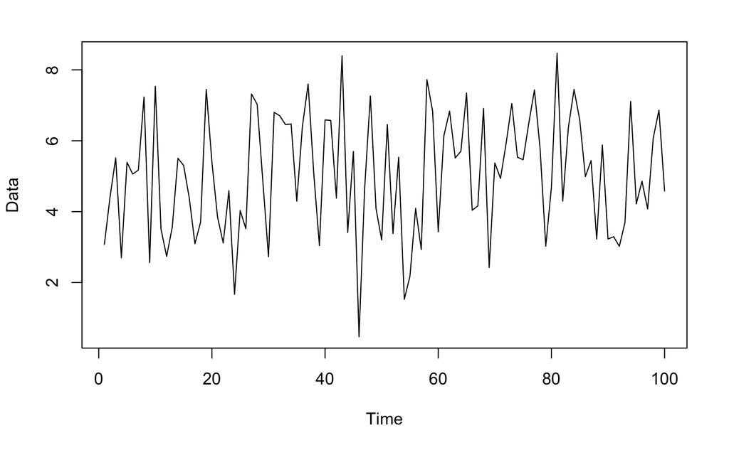

```r
set.seed(3)
mu = 5
sigma = 2
# rnorm draws a random number from a normal distribution with some mean and standard deviation
data = mu + rnorm(100, mean=0, sd=sigma)
plot(data, ylab='Data', xlab="Time", type="l")
```

The likelihood of the `data` given $\mu = 5$ and $\sigma = 2$ is

$$L(\mu = 5, \sigma = 2 | y_{1, \text{obs}}, y_{2, \text{obs}}, \dots, y_{100, \text{obs}}) = \prod_{t=1}^{100} \text{Normal}(y_{t, \text{obs}} | \mu = 5, \sigma = 2)$$

`dnorm` gives us the probability density function for a normal distribution so we can calculate this as

```r
# Compute the likelihood. prod is a function that takes a product of a vector.
likelihood = prod(dnorm(data, mean=mu, sd=sigma))
likelihood
```

```
[1] 1.700149e-86
```

Notice that this number is really, really small. That is ok. However, it is almost always more convenient and numerically more stable to work with the negative log-likelihood. Take the negative log of each side of the likelihood equation, use some nice log rules, and you get

$$-\log(L(\Theta | Y)) = -\sum_{t = 1}^n \log(p(y_t | \Theta))$$

There is nothing fancy going on here. Negative log-likelihood is just more convenient to work with that likelihood. Moreover, because we tend to use negative log-likelihood we now want the best fit parameter set that minimizes the negative log-likelihood.

### Exercise: Compute the negative log-likelihood

> For our toy model above, compute the negative log-likelihood. Using the function `dnorm` with the argument `log=TRUE` will return log probabilities.

```r
# HIDE ME IF YOU DON'T WANT TO SEE THE ANSWER
negative_ll = -1*sum(dnorm(data, mean=mu, sd=sigma, log=T))
negative_ll
```

```
[1] 197.4916
```

What if we wanted to find the parameter $\mu$ that maximizes the likelihood (minimizes the negative log-likelihood), given $\sigma = 2$? We would hope it was around 5 since this is the parameter we used to generate the data.

Conceptually, we can do this by trying a bunch of different values of $\mu$ and seeing which one leads to the smallest negative log-likelihood given the data set. Let’s try it

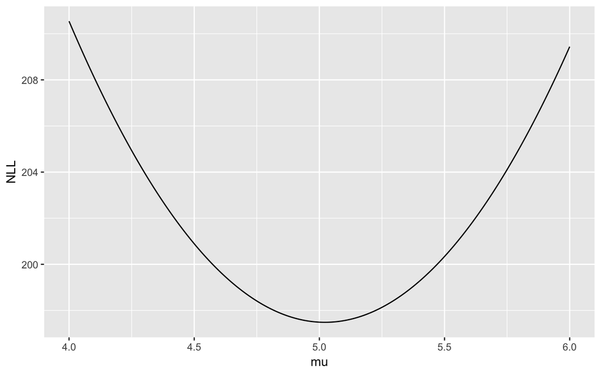

```r
# Try 1000 mu vals between 4 and 6
mu_vals = seq(4, 6, length=1000)
nlls = array(NA, dim=length(mu_vals))
# Loop through all mu values and compute the nll.
for(i in 1:length(mu_vals)){
  nlls[i] = -1*sum(dnorm(data, mean=mu_vals[i], sd=sigma, log=T))
}
# Here is a more efficient way to this that gives the same answer
nlls_efficient = sapply(mu_vals, function(tmu) -1*sum(dnorm(data, mean=tmu, sd=sigma, log=T)))
ggplot(data=NULL, aes(x=mu_vals, y=nlls)) + geom_line() + ylab("NLL") + xlab("mu")
```

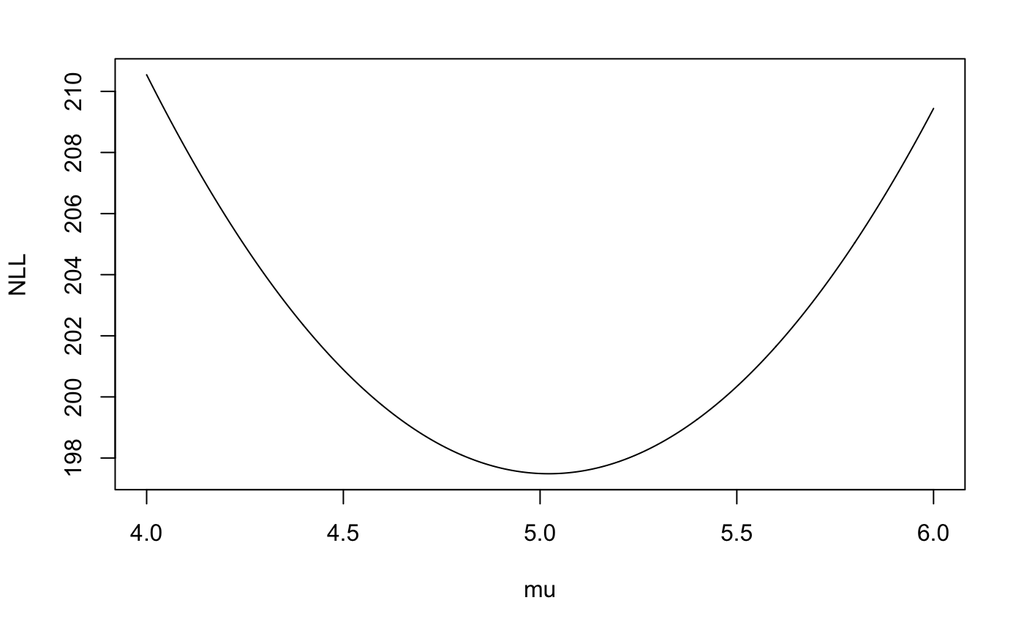

```r
# Or with base plot
plot(mu_vals, nlls, type="l", ylab="NLL", xlab="mu")
```

As we’d expect, the $\mu$ value with the smallest negative log-likelihood give that data is around 5 (though not exactly 5, why?). This briefly illustrates that by minimizing the negative log-likelihood we can estimate parameters in our model.

## Likelihood in practice: Application to the influenza data

Let’s try using these likelihood concepts on the influenza data. Let’s assume that sick boys in bed are actually counted sloppily such that they are under or over-reported. We will assume that the way in which sick boys in bed are miscounted follows a Poisson distribution. A Poisson distribution is a often-used distribution for count data. It is defined by one parameter $\lambda$ and mean = variance = $\lambda$. In a more rigorous analysis, the assumption of Poisson measurement error is an assumption that we would need to test.

Consider the following measurement error model where SIBR$_{\text{B}, t | \beta, \gamma, \delta}$ is the SIBR model prediction for the number of boys confined to bed ($B$) at time $t$ given the parameters $\beta, \gamma, \delta$.

$$\begin{align}
B_t &= \text{SIBR}_{\text{B}, t | \beta, \gamma, \delta} \\
B_{\text{obs}, t} &\sim \text{Poisson}(B_t)
\end{align}$$

We can simulate this model just as before and now incorporate our Poisson-distributed measurement error.

```r
# Use the best fit parameters from the SSE estimation
best_params_lsq = fit1$par
ode_sim = as.data.frame(ode(y=xinit, parms=best_params_lsq, func=sibr_model, times = times))
```

Add Poisson measurement error to each observation

```r
# Add random poisson measurement error
B_obs = with(ode_sim, rpois(length(B), B))
ode_sim$B_obs = B_obs
```

Plot the simulation

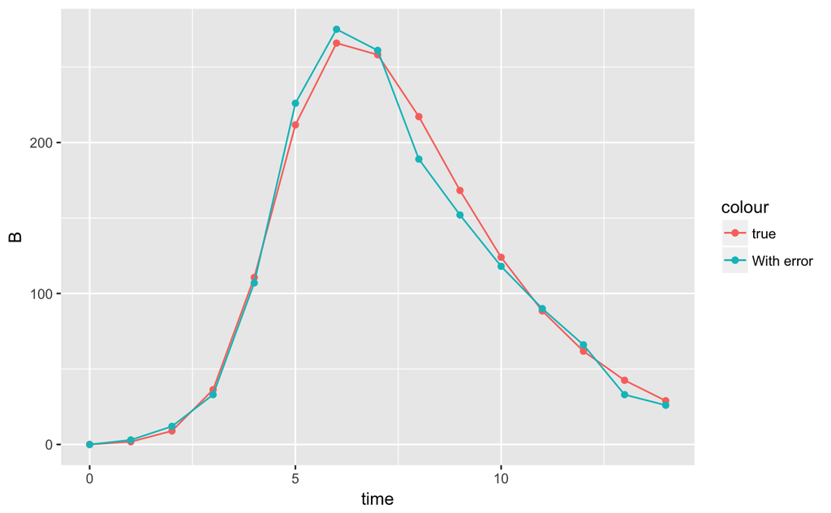

```r
ggplot(data=ode_sim, aes(x=time, y=B, color="true")) + geom_line() +
            geom_point() + geom_point(aes(x=time, y=B_obs, color="With error")) +
            geom_line(aes(x=time, y=B_obs, color="With error"))
```

## Exercise: Calculating likelihood for the influenza data

> 1. Calculate the negative log-likelihood of the observed influenza data given the best fit sum of squared error parameters and Poisson measurement error.
> 2. Next assume that the simulated data above (the blue line) is the actual data. Calculate the negative log-likelihood of this “data” using the same procedure as above.
> 3. Is the actual influenza data or the simulated influenza data more “likely”" given the parameters (i.e. which one has a lower negative log-likelihood)? Does this agree with what you would expect? Why or why not? Simulate the data with Poisson measurement error again and see if your answer changes.

> **Hint**: Use the R function `dpois` to compute the probability of multiple observations. For example, take the observations `obs = c(2, 3, 3, 5)` that were drawn from Poisson distributions with means `means = c(3, 3, 5, 6)`. The probability of each of these data points could be computed using `dpois(obs, means)`. The log probability could be computed using `dpois(obs, means, log=TRUE)`(see `?dpois` for more information).

```r
# HIDE ME IF YOU DON'T WANT TO SEE THE ANSWER
# Calculating the negative log-likelihood
nll_obs = -1*sum(dpois(flu$flu, ode_sim$B[-1], log=T))
nll_sim = -1*sum(dpois(B_obs[-1], ode_sim$B[-1], log=T))
print(c(nll_obs, nll_sim))
```

```
[1] 96.10016 48.32175
```

Now let’s write a generic function that will calculate the negative log-likelihood for a given parameter set

```r
sibr_nll = function(beta, gamma, delta){

  # Setting initial conditions and parameters just like before
  times = c(0, flu$day)
  params = c(beta=beta, gamma=gamma, delta=delta)
  init_vals = c(S=762, I=1, B=0, R=0)
  ode_res = as.data.frame(ode(func=sibr_model,
                                y=init_vals,
                                times=times,
                                parms=params))
  # Removing the initial condition
  nll = -1*sum(dpois(flu$flu, ode_res$B[2:15], log=TRUE))
  return(nll)

}
# Test that the function is working
start_params = as.vector(best_params_lsq)
sibr_nll(start_params[1],
         start_params[2],
         start_params[3])
```

```
[1] 96.10016
```

Let’s use the function we just wrote (`sibr_nll`) and define a quick utility function that allows us to hold all parameters fixed except for the transmission rate $\beta$. This will allow us to explore how varying $\beta$ changes the negative log-likelihood.

```r
nll_beta = function(par){

  return(sibr_nll(beta=par[1],
           start_params[2],
           start_params[3]))
}
```

Now let’s vary $\beta$ and see what happens to the negative log-likelihood.

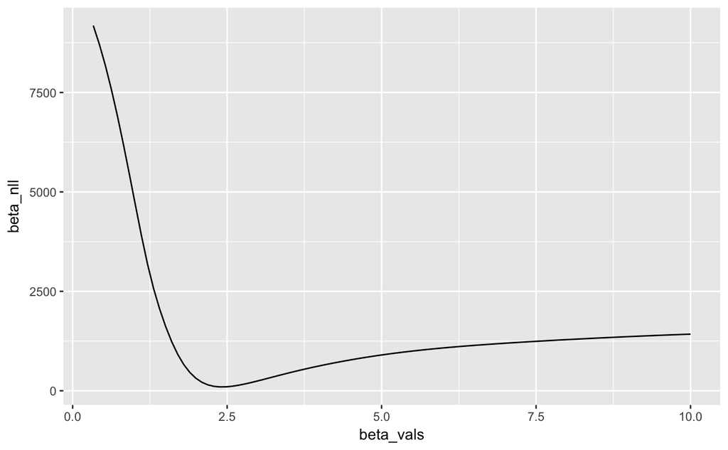

```r
# A range of beta values to explore
beta_vals = seq(1/3, 10, length=100)
beta_nll = sapply(beta_vals, nll_beta)
ggplot(data=NULL, aes(x=beta_vals, y=beta_nll)) + geom_line()
```

Notice that there is a clear minimum in the nll around

```r
beta_vals[which.min(beta_nll)]
```

```
[1] 2.383838
```

so *given the fixed values of the other parameters*, our maximum likelihood estimate for $\beta$ is around 2.35 - 2.45

We can do this a bit more formally using the `optim` function again

```r
fit_beta = optim(2, nll_beta, method="Brent", lower=2, upper=3)
fit_beta
```

```
$par
[1] 2.417992

$value
[1] 95.91741

$counts
function gradient
      NA       NA

$convergence
[1] 0

$message
NULL
```

The option `method=Brent` specifies a specific optimization method that searches a bounded region for the minimum. In this case, we set the bounds for that region using `lower=2` and `upper=3`.

## Exercise: Find the conditional MLE of $\gamma$

> Using the same steps as above, fix $\beta$ and $\delta$ and find the MLE of $\gamma$ given the fixed parameters.

```r
# HIDE ME IF YOU DON'T WANT TO SEE THE ANSWER
# MLE function for gamma given fixed beta and delta
nll_gamma = function(par){

  return(sibr_nll(beta=start_params[1],
           gamma=par[1],
           delta=start_params[3]))
}
# Using optim.
fit_gamma = optim(2, nll_gamma, method="Brent", lower=0.7, upper=1.2)
fit_gamma
```

```
$par
[1] 0.954873

$value
[1] 95.25881

$counts
function gradient
      NA       NA

$convergence
[1] 0

$message
NULL
```

## Finding MLEs of multiple parameters simultaneously

We just found the MLE of $\beta$ conditional on fixed values of other parameters. What if we want to jointly maximize the likelihood for all parameters simultaneously? Theoretically, this is no problem given enough data. Realistically, it can sometimes be quite challenging and there is a lot of research on the best ways to do this. While it is beyond the scope of our discussion here, keep in mind that simultaneously estimating multiple parameters can be challenging depending on how informative your data is.

To fit multiple parameters simultaneously, we could again use `optim`. However, the `mle2` function in the `bbmle` package provides some nice additional features that we will use later.

```r
library(bbmle)
# Get the mle estimates for my parameters
fit_all = mle2(sibr_nll,
               start=list(beta=start_params[1],
                          gamma=start_params[2],
                          delta=start_params[3]),
               method="L-BFGS-B",
               lower=c(0, 0, 0),
               upper=c(Inf, Inf, Inf))
```

The arguments are a bit different here.

1. `sibr_nll`: This is the negative log-likelihood function that we want to minimize
2. `start`: This is a list where the named items correspond to parameters in our `sibr_nll` function. These are starting values for each of the parameters we want to estimate using MLE. You want to try to choose starting values that are at least somewhat close to the MLE estimates, otherwise the optimizer will really struggle to find the MLE estimates.
3. `method`: This specifies the minimization routine to use. In this case we are using “L-BFGS-B”, which is an optimizer that requires a lower and upper bound.
4. `lower` and ’upper`: Vectors that specify the lower and upper bounds for the parameters you are estimating.

We can look at the coefficient estimates and we can see that they are not all that different from our least squares estimates.

```r
coef(fit_all)
```

```
     beta     gamma     delta
2.3924026 0.9177815 0.4583135
```

```r
best_params_lsq
```

```
     beta     gamma     delta
2.4029047 0.9092372 0.4123194
```

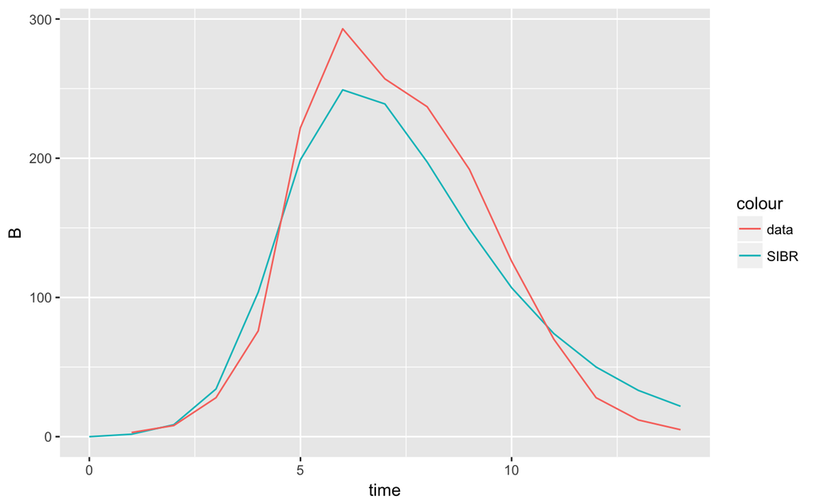

```r
sibr_sim = as.data.frame(ode(y=init_vals, parms=fit_all@coef, time=times, func=sibr_model))
ggplot(sibr_sim, aes(x=time, y=B, color="SIBR")) +
              geom_line() + geom_line(data=flu, aes(x=day, y=flu, color="data"))
```

The real advantage is now we can get confidence intervals for these parameters

```r
# Calculate profile likelihood
pfit = profile(fit_all)
```

```r
confint(pfit)
```

```
          2.5 %    97.5 %
beta  2.2919716 2.5234338
gamma 0.7656299 1.1022379
delta 0.4274706 0.4886275
```

### Using the uncertainty to estimate CIs for derived statistics

We also could use additional results stored in `fit_all` to estimate uncertainty around other derived statistics of interest in our model. For example, $R_0$ in this model is $\frac{\beta}{\gamma}$. The MLE estimate of $R_0$ is then

```r
R0 = as.numeric(fit_all@coef['beta'] / fit_all@coef['gamma'])
print(R0)
```

```
[1] 2.606724
```

What is the uncertainty around this estimate? Well`fit_all` provides us with a co-variance matrix for our parameters of interest.

```r
covar = fit_all@vcov
covar
```

```
               beta         gamma         delta
beta   0.0033584982  0.0044669946 -0.0006345456
gamma  0.0044669946  0.0072590233 -0.0008948167
delta -0.0006345456 -0.0008948167  0.0002396468
```

```r
# Correlation matrix
S = diag(sqrt(diag(covar)))
solve(S) %*% fit_all@vcov %*% solve(S)
```

```
           [,1]       [,2]       [,3]
[1,]  1.0000000  0.9046983 -0.7073013
[2,]  0.9046983  1.0000000 -0.6784364
[3,] -0.7073013 -0.6784364  1.0000000
```

With this co-variance matrix, we could either use something called the [delta method](http://www.math.umt.edu/patterson/Delta.pdf) to get the uncertainty around $R_0$ or, my personal favorite, brute force simulation.

The brute force simulation approach follows four steps

1. Assume that the parameter estimates follow a multivariate Normal distribution with the mean being the MLE parameter estimates and the co-variance matrix being the estimated co-variance matrix. This is asymptotically true for all MLE estimates as sample size gets large so it is not that crazy of an assumption.
2. Draw a large number of parameter vectors from this multivariate distribution.
3. Calculate the statistic of interest ($R_0$ in our case) for all random draws. This gives you a distribution of the statistic.
4. Compute the your desired quantiles from this distribution.

For example,

```r
library(MASS) # Contains a function to sample from a multivariate normal distribution
# Sample parameter vector from multivariate normal distribution
samps = mvrnorm(1000, mu=fit_all@coef, fit_all@vcov)
# Compute a distribution of R0
R0_distribution = samps[, 'beta'] / samps[, 'gamma']
# Get the 95% CI for this distribution.
quantile(R0_distribution, c(0.025, 0.5, 0.975))
```

```
    2.5%      50%    97.5%
2.316233 2.620324 3.036823
```

Doesn’t look like there is much doubt that, **given our estimated parameters and our assumed model**, $R_0 > 1$.

## Comparing models fit with maximum likelihood

A benefit of using maximum likelihood to fit your models, is that there are well-established ways for comparing different models. One way of comparing models is using the Akaike information criterion (AIC) which is defined as

$$AIC = -2\ln(L(\theta_{MLE} | Y)) + 2k$$

where $\theta_{MLE}$ are the maximum likelihood estimate parameters given the data and $k$ is the number of parameters that were fit. The first term in the AIC equation is two times the negative log-likelihood of the model under the MLE parameters and this is measures how well the model fits the data. However, because more complex models almost always fit the data better, the second term in the model penalizes more complex models. Therefore, the AIC is trying to find a balance between models that fit the data well and models that are relatively simple. This is the well-known bias-variance trade-off that is often discussed in statistics. When comparing a set of models, **the model with the lowest AIC is the perferred model**.

We could calculate the AIC for our best fit model with the following code

```r
nll = fit_all@min
k = 3
AIC = 2*nll + 2*k
print(AIC)
```

```
[1] 178.6788
```

or by using the `AIC` function in R

```r
AIC(fit_all)
```

```
[1] 178.6788
```

Of course, a single AIC value doesn’t mean anything. So we want another model to compare it to.

### Exercise: Compare an SIR to the SIBR model

> 1. Code up an SIR model in which the measurement error follows a Poisson distribution.
> 2. Assume that the boys confined to bed corresponds to the infected class of the SIR model and fit the model using maximum likelihood.
> 3. Compute the AIC of the SIR model and compare it to the SIRB model. Which model does AIC indicate is preferable?
> 4. Compute $R_0$ for the SIR model. Did your estimate for $R_0$ change (see Wearing et al. 2005, Plos Medicine)?

```r
# HIDE ME IF YOU DON'T WANT TO SEE THE ANSWER
SIR.model <- function (t, x, params) {
  # SIR model

  S = x[1]
  I = x[2]
  R = x[3]
  beta = params[1]
  gamma = params[2]
  N = 763

  dSdt = -beta*S*I/N
  dIdt = beta*S*I/N - gamma*I
  dRdt = gamma*I

 return(list(c(dSdt,dIdt,dRdt)))
}
sir_nll = function(beta, gamma){

  # Setting initial conditions and parameters just like before
  times = c(0, flu$day)
  params = c(beta, gamma)
  init_vals = c(S=762, I=1, R=0)
  ode_res = as.data.frame(ode(func=SIR.model,
                                y=init_vals,
                                times=times,
                                parms=params))
  # Removing the initial condition
  nll = -1*sum(dpois(flu$flu, ode_res$I[2:15], log=TRUE))
  return(nll)

}
# Get the mle estimates for my parameters
fit_all_sir = mle2(sir_nll,
               start=list(beta=start_params[1],
                          gamma=start_params[2]),
               method="L-BFGS-B",
               lower=c(0, 0),
               upper=c(Inf, Inf))
# Look at coefficients
print(fit_all_sir@coef)
```

```
     beta     gamma
1.6873795 0.4769168
```

```r
print(c(R0=as.numeric(fit_all_sir@coef['beta']) / as.numeric(fit_all_sir@coef['gamma'])))
```

```
    R0
3.5381
```

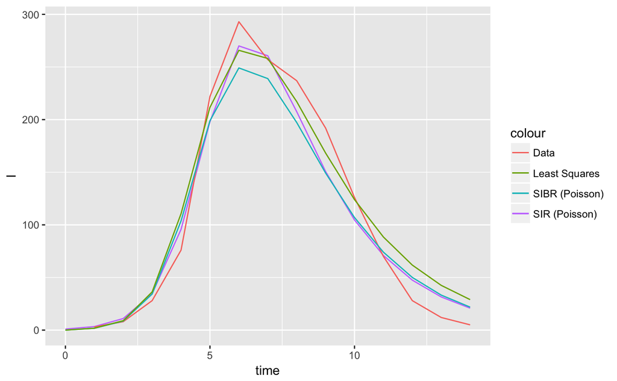

```r
# Plot the results comparing the various trajectories
sir_sim = as.data.frame(ode(y=c(S=762, I=1, R=0), times = times, func=SIR.model, parms = fit_all_sir@coef))
ggplot(data=sir_sim, aes(x=time, y=I, color="SIR (Poisson)")) + geom_line() +
    geom_line(data=flu, aes(x=day, y=flu, color="Data")) +
    geom_line(data=sibr_sim, aes(x=time, y=B, color="SIBR (Poisson)")) +
    geom_line(data=best_mod_lsq, aes(x=time, y=B, color="Least Squares"))
```

```r
# Compare SIR and SIBR models with AIC
AIC(fit_all_sir, fit_all)
```

| AIC | df |
| --- | --- |
| 157.1350 | 2 |
| 178.6788 | 3 |